# Regression Discontinuity Design

Cutoffs, Local Average Treatment Effects, and Sharp vs. Fuzzy Designs

Professor Benjamin Noble

## Politics Pays?

[figure not shown]

Ben Sasse, via Higher Ed Dive

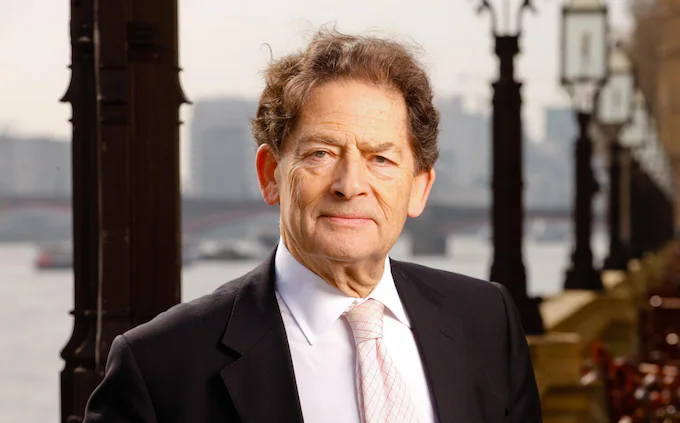

Nigel Lawson

## Eggers and Hainmueller (2009)

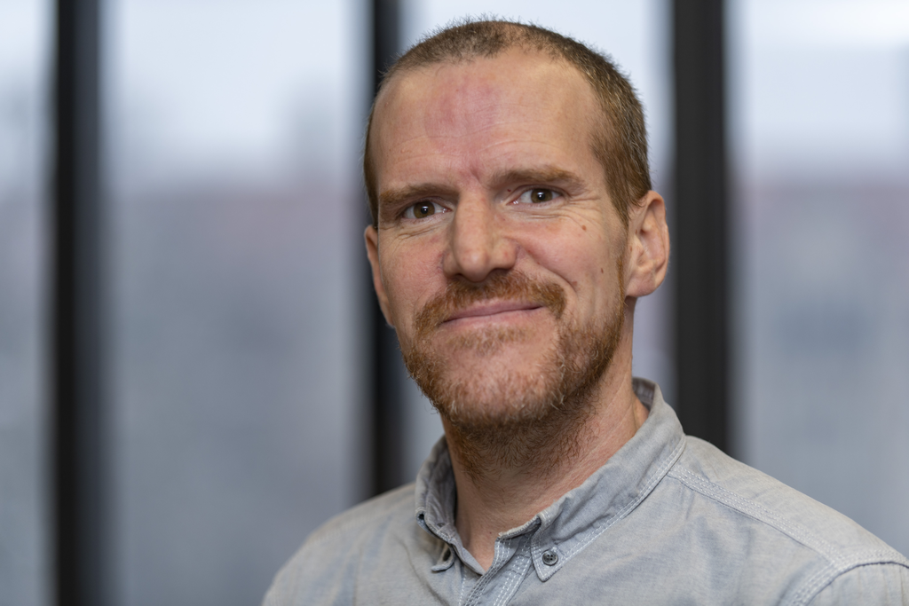

Eggers

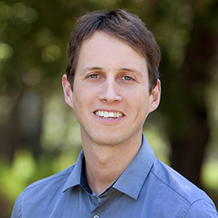

Hainmueller

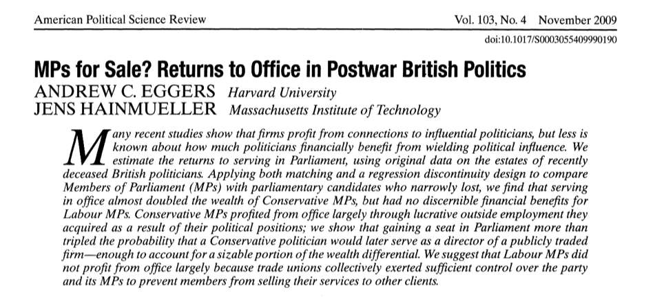

## The Problem

> “MPs are not randomly selected from the population (which is unfortunate for researchers, but arguably beneficial for citizens), so a comparison of MPs’ income or wealth with that of a peer group outside politics is likely to reflect factors that led MPs to gain political office as well as the value of political office itself.” (Eggers and Hainmueller 2009, 513–14)

## The Solution

- Compare politicians who **narrowly won** to politicians who **narrowly lost**.
- A landslide winner and a big loser are very different.
- Near 50% (e.g., 50.1 vs 49.9), winning is essentially luck (e.g., rain, traffic).
- Near winners and near losers are *almost* randomly assigned.

## The Evidence

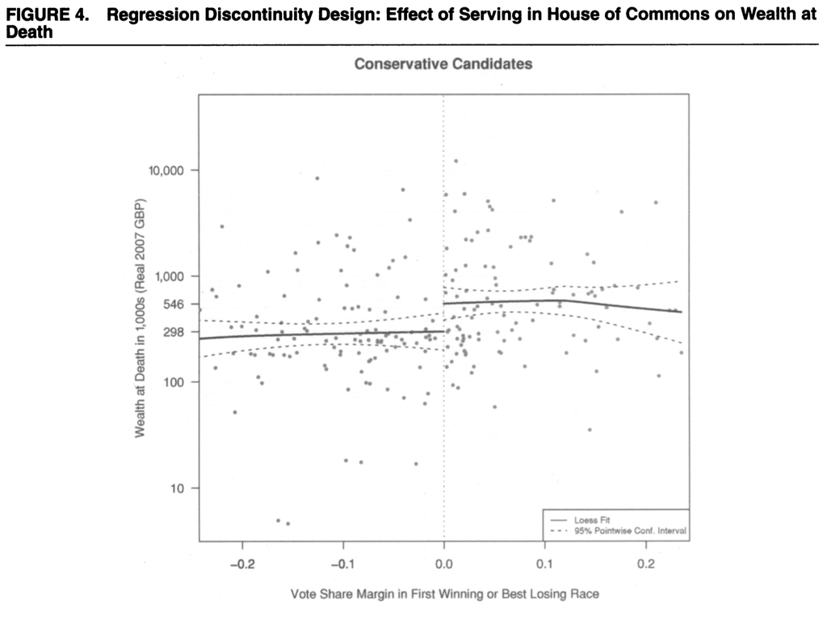

Eggers and Hainmueller (2009)

## Am I a Good Teacher? (Redux)

- **Good:** score on a 100-point data analysis test.
- Suppose we have a binary treatment variable:

$$D_i =
\begin{cases}
1 & \text{if } i \text{ takes POLI 170} \\
0 & \text{if } i \text{ does not take POLI 170}
\end{cases}$$

- Suppose we have an outcome variable, $Y_i$, person $i$’s score on the test.

## Test Scores by POLI 30 Grade

- Suppose: to take this class, you must have a POLI 30 score ≥ 75.
- Everyone who applies (admitted or not) takes the same final exam afterward.
- **A problem:** We are creating selection bias. Students in treatment (taking the class) are better at statistics.
- A naive comparison of a POLI 30 student who scored 50 vs. 90 is not credible.

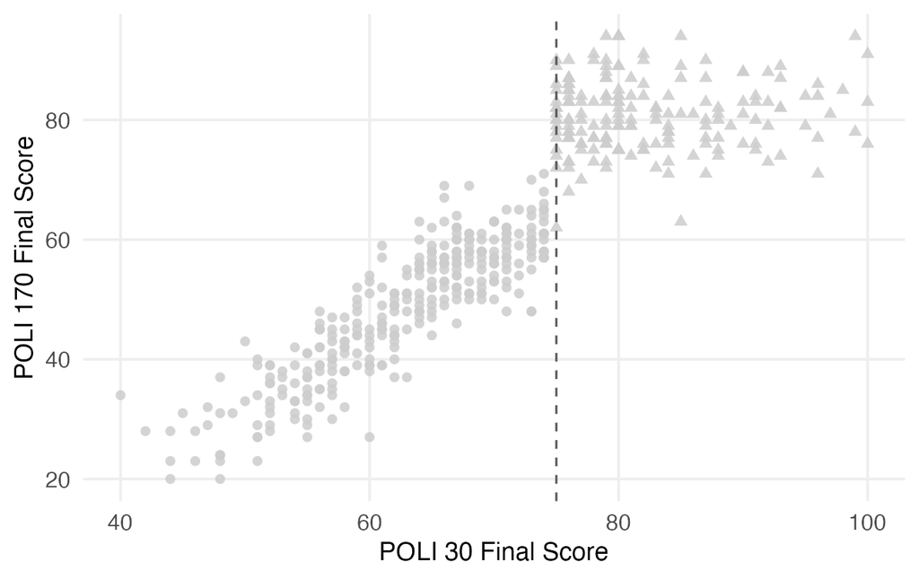

## Looking Near the Cutoff

- Students who scored 74 vs. 76 are essentially the same. Tiny chance differences determine which side of the line they land on.
- **Regression Discontinuity Design (RDD):** exploit the cutoff by looking at near-cutoff observations that are quasi-randomly assigned.

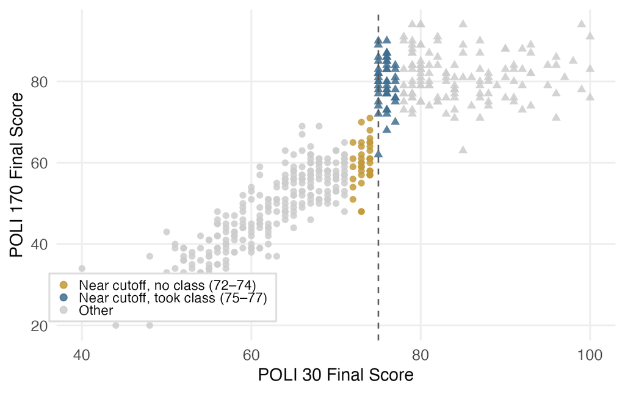

## Some Notation and Terminology

- Forcing variable / running variable (e.g., POLI 30 grade): $c_i$
- Treatment assignment (taking POLI 170):

$$D_i =
\begin{cases}
1 & \text{if } c_i \geq c^* \\
0 & \text{if } c_i < c^*
\end{cases}$$

- **No overlap:** every treated unit has $c_i \geq c^*$; every control unit has $c_i < c^*$. No value of $c_i$ ever appears in both groups.

## The Naive Regression

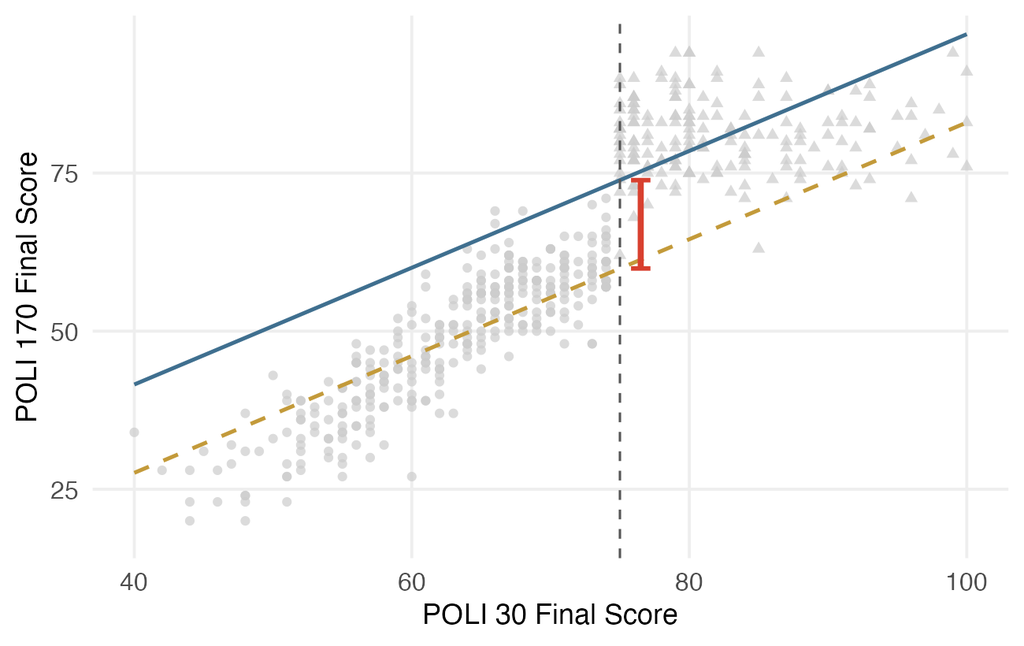

`lm(post_score ~ took_class + pre_score, data = df)`

| Term | Estimate | Std. Error | p-value |
| --- | --- | --- | --- |
| (Intercept) | -9.34 | 2.68 | < .001 |
| took_class | 13.96 | 1.05 | < .001 |
| pre_score | 0.92 | 0.04 | < .001 |

## LATE: Local Average Treatment Effect

- The “true” treatment effect:
  $$LATE = \mathbb{E}[Y_i^1 - Y_i^0 \mid c_i = c^*]$$
- We have *no overlap* at $c^*$, so we estimate an outcome model for values close to the cutoff:
  $$Y_i = \beta_0 + \beta_1 D_i + \beta_2 c_i + \varepsilon_i$$
- The estimated LATE is $\widehat{LATE} = \hat{\beta}_1$.

## Restricting to the Window

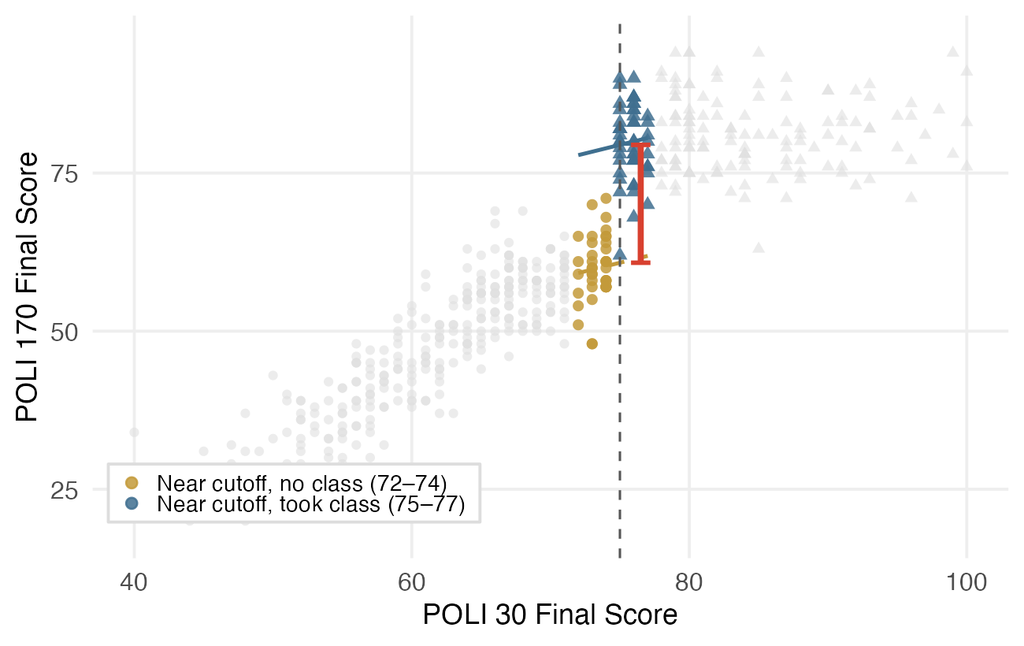

```
lm(post_score ~ took_class + pre_score,
  data = df %>% filter(between(pre_score, 72, 77)))
```

| Term | Estimate | Std. Error | p-value |
| --- | --- | --- | --- |
| (Intercept) | 20.24 | 59.22 | 0.733 |
| took_class | 18.64 | 2.31 | < .001 |
| pre_score | 0.54 | 0.81 | 0.504 |

## Assumptions and Limitations

- We need a lot of data around the discontinuity.
- Local randomization near the cutoff: $(Y_i^1, Y_i^0) \perp D_i$ for $c_i \in (c^* - a, c^* + a)$.
- No sorting / continuity at the cutoff (violations: other treatments, manipulation of scores).

## McCrary Density Test (2008)

- If people sort around the cutoff, we might see it in the density of the running variable.
- **Limitation:** only catches obvious violations. Complement it with covariate checks and placebo tests at other cutoffs.

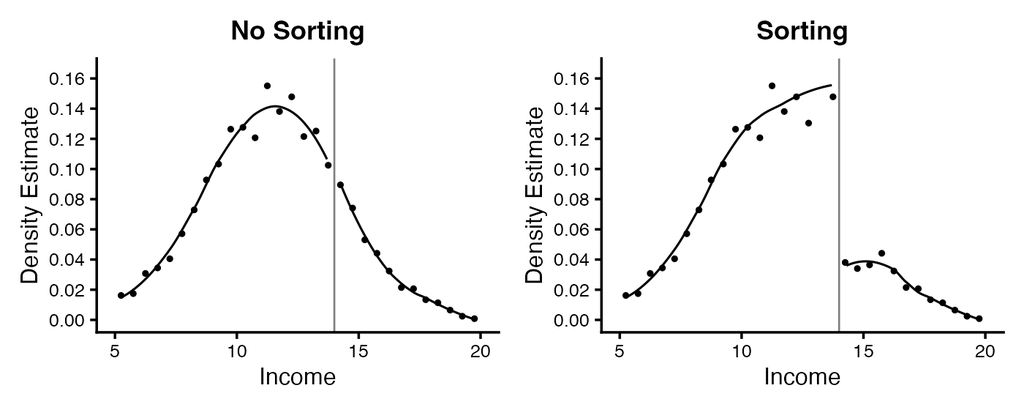

## Bandwidths…

- How close is “close”?
- One solution: show many “bandwidths” and hope they generally give you the same results.

| Lower | Upper | LATE est. |
| --- | --- | --- |
| 74 | 76 | 17.76 |
| 73 | 77 | 19.34 |
| 72 | 78 | 18.81 |
| 71 | 79 | 18.37 |
| 70 | 80 | 18.34 |
| 69 | 81 | 18.53 |
| 68 | 82 | 18.98 |
| 67 | 83 | 19.64 |
| 66 | 84 | 20.63 |
| 65 | 85 | 20.06 |

## Sharp vs Fuzzy RDD

- **Sharp:** cutoff perfectly separates treatment and control.
- **Fuzzy:** cutoff generally, but imperfectly, separates treatment and control.
  - Think of this like an instrumental variables / encouragement design.

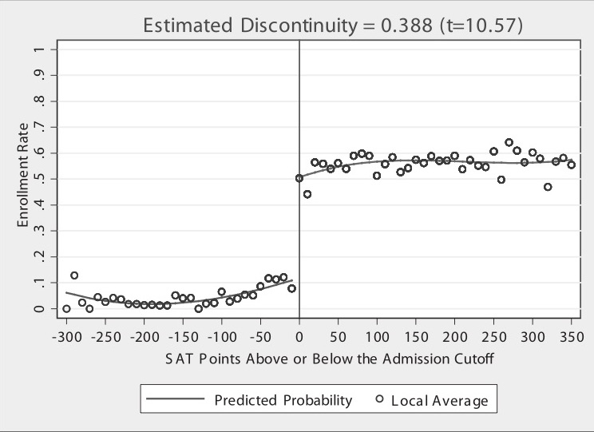

Hoekstra (2009) via Cunningham (2021)